# Hypothesis testing for the counts of graffiti in two areas of Vancouver

Kangbo Lu, Siqi Zhou, Mitchie Zhao, Mengyuan Zhu  
2020/11/26 (updated: 2020-12-10)

- Summary
- Introduction
- Methods
  - Exploratory Data Analysis
  - Statistical Analysis
  - Results & Discussion
- References

# Summary

In this research project, we tried to answer the research question of whether the number of graffiti in Vancouver’s Downtown area is the same as the number of graffiti in Vancouver’s Strathcona area.

Due to the skewness of our sample distribution, we used the median as the test statistics and set the *α* = 0.05 with the two-tailed permutation test method to study the difference in the medians.

# Introduction

Here we attempted to conduct a hypothesis test with a suitable test flavor to answer the statistical research question, that is, whether the number of graffiti in Vancouver’s downtown area differs from the number of graffiti in Vancouver’s Strathcona area (City of Vancouver 2020).

We proposed to sequentially perform an exploratory data analysis, determine what features and columns to be retrieved to support our hypothesis testing, and attach with a suitable test flavor to verify whether the median number of graffiti per location of Vancouver’s downtown area differs from the median number of graffiti per location of Vancouver’s Strathcona area (Ismay and Kim 2019).

According to the data visualizations, a suitable estimator for our research question is the median, since we are interested in the most common numbers of graffiti in the two regions and the median is not sensitive to extreme values as it is mathematically defined by the the 50th percentile of a distribution (Bzik 2014).

The R and Python programming languages (R Core Team 2020; Van Rossum and Drake 2009) and the following R and Python packages were used to perform the analysis: docopt (de Jonge 2018), knitr (Xie 2020), tidyverse (Wickham et al. 2019), ggplot2 (Wickham 2016), infer (Bray et al. 2020). The code used to perform the analysis and create this report can be found here: https://github.com/UBC-MDS/DSCI_522_Group_34/blob/main/src/analysis.R.

# Methods

## Exploratory Data Analysis

The dataset used in this project provides information on the location of sites with graffiti identified by City staff. It was sourced from the Vancouver Open Data Portal, specifically [this file](https://opendata.vancouver.ca/explore/dataset/graffiti/information). The license of data can be found [here](https://opendata.vancouver.ca/pages/home/).

There are 8,028 rows and 3 columns in our dataset. Each row in the dataset records the number of graffiti incidents by the geographic area of Vancouver along with the spatial representation of the location by coordinates stored in JSON format.

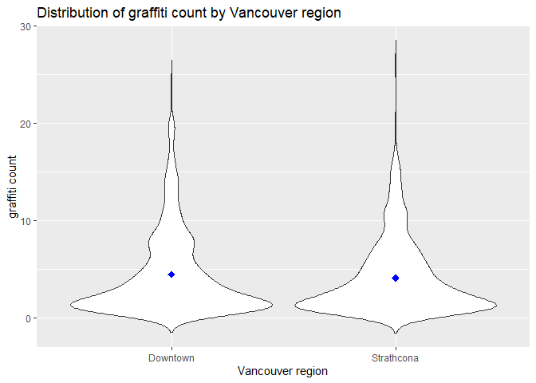

Figure 1. Distribution of graffiti count by Vancouver region: downtown and Strathcona area

We are investigating 2 local areas of Vancouver; they are the ‘Downtown’ and the ‘Strathcona’ regions, and there are 2,121 observations related to our research interest. After conducting the exploratory data analysis, we chose the median as the estimator. From the above violin plot of the distributions of two classes, we can observe the sample distributions are skewed to the right. The long right tail of the distributions also makes the median a suitable test flavor, since the median is not sensitive to extreme values as it is mathematically defined by the 50th percentile of a distribution.

## Statistical Analysis

To estimate the sampling distribution of the test statistic we need many samples generated under the null hypothesis. If the null hypothesis is true, changing the exposure would have no effect on the outcome. By randomly shuffling the exposures we can make up as many ‘null’ data sets as we like. If the null hypothesis is true, the shuffled data sets should look similar to the real data. Otherwise, they should look different from the real data. Comparing the shuffled test statistics to the real test statistics gives a p-value. Then, we compared the p-value with our defined threshold *α* = 0.05 to draw the conclusion for our research question.

**Estimator:**  
The median of the number of graffiti per recorded location

**Hypothesis**  
*H*<sub>0</sub>: The median of the number of graffiti per recorded location of Vancouver’s Downtown area is the same as the median of the number of graffiti per recorded location of Vancouver’s Strathcona area

*H*<sub>*a*</sub>: The median of the number of graffiti per recorded location of Vancouver’s Downtown area is not the same as the median of the number of graffiti per recorded location of Vancouver’s Strathcona area

**Test Flavor**  
Two-tailed permutation test for the median.

**Test Statistics**  
We used delta to represent the difference between the median counts of graffiti in each area.

## Results & Discussion

First we calculated the median values of the counts in the 2 areas of our interest. The medians of the counts of graffiti per location in the two areas are listed below:

| geo_local_area | median_count |
| --- | --- |
| Downtown | 3 |
| Strathcona | 3 |

Table 1. Results of computed median values of the 2 classes

To look at whether our null hypothesis is valid, we conducted a simulation with 10000 permutation replicates of the differences in medians. The figure below visualizes the simulated null distribution with the test statistics.

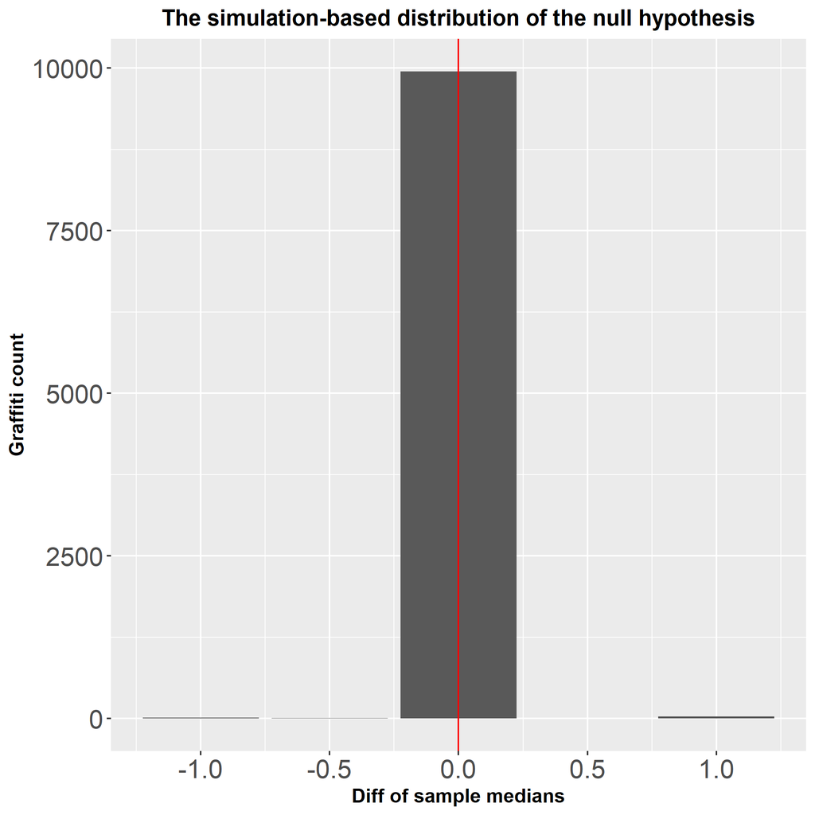

Figure 2. The simulation-based distribution of the null hypothesis

Then, we calculated the corresponding p-value of the null distribution for drawing the conclusion:

| delta_sample | p_value |
| --- | --- |
| 0 | 1 |

Table 2. The corresponding p-value of the null hypothesis

The test statistics is 0 for the sample. The calculated p-value is 1, which is larger than 0.05. It indicated that there is no statistically significant difference between the medians of counts of graffiti per recorded location in the 2 areas in Vancouver. We don’t have enough confidence to reject the null hypothesis that the median of the number of graffiti per recorded location of Vancouver’s Downtown area is the same as the median of the number of graffiti per recorded location of Vancouver’s Strathcona area.

Future work includes further exploratory data analysis to take full advantage of the coordinate data on the map, and to understand the distribution of graffiti in different areas of Vancouver. Analyzing the Downtown and Strathcona areas is a bit segmentary to represent the whole regional situation of Vancouver. We would study and observe the graffiti numbers and differences in other areas based on a more macroscopic perspective. Another hypothesis testing might be conducted as a statistical analysis comparison of our current permutation test. Meanwhile, we would also improve the preprocessing to eliminate redundant and unrepresentative data points since there are many zero values in Downtown and Strathcona areas, leading to a very centralized distribution.

# References

Bray, Andrew, Chester Ismay, Evgeni Chasnovski, Ben Baumer, and Mine Cetinkaya-Rundel. 2020. *Infer: Tidy Statistical Inference*. https://CRAN.R-project.org/package=infer.

Bzik, Thomas J. 2014. *Quantile Estimation*. ASTM Standardization. https://www.astm.org/SNEWS/images/ja14_dp.pdf.

City of Vancouver. 2020. *Graffiti*. https://opendata.vancouver.ca/explore/dataset/graffiti/information/.

de Jonge, Edwin. 2018. *Docopt: Command-Line Interface Specification Language*. https://CRAN.R-project.org/package=docopt.

Ismay, Chester, and Albert Y. Kim. 2019. *Statistical Inference via Data Science: A Moderndive into R and the Tidyverse*. New York: Chapman; Hall/CRC.

R Core Team. 2020. *R: A Language and Environment for Statistical Computing*. Vienna, Austria: R Foundation for Statistical Computing. https://www.R-project.org/.

Van Rossum, Guido, and Fred L. Drake. 2009. *Python 3 Reference Manual*. Scotts Valley, CA: CreateSpace.

Wickham, Hadley. 2016. *Ggplot2: Elegant Graphics for Data Analysis*. Springer-Verlag New York. https://ggplot2.tidyverse.org.

Wickham, Hadley, Mara Averick, Jennifer Bryan, Winston Chang, Lucy D’Agostino McGowan, Romain François, Garrett Grolemund, et al. 2019. “Welcome to the tidyverse.” *Journal of Open Source Software* 4 (43): 1686. https://doi.org/10.21105/joss.01686.

Xie, Yihui. 2020. *Knitr: A General-Purpose Package for Dynamic Report Generation in R*. https://yihui.org/knitr/.